# itan

### Correlación Biserial Puntual

El coeficiente de correlación biserial puntual entre una alternativa y el puntaje total de la prueba permite determinar el nivel de asociación entre seleccionar una alternativa con el puntaje total de la prueba.

Para su cálculo se utiliza la siguiente función:

$$r_{bp} = \frac{\overline{X_{p}}-\overline{X_{q}}}{\sigma_{X}}\sqrt{p \cdot q}$$

Donde

- $p$ es la proporción de estudiantes que respondió la alternativa examinada,
- $q$ es la proporción de estudiantes que seleccionó una alternativa diferente a la alternativa examinada
- $\overline{X_{p}}$ es el promedio del puntaje obtenido en la prueba por los estudiantes que seleccionaron la alternativa examinada.
- $\overline{X_{q}}$ es el promedio del puntaje obtenido en la prueba por los estudiantes que no seleccionaron la alternativa en cuestión.
- $\sigma_X$ es la desviación estándar del puntaje obtenido en la prueba de todos los estudiantes. Para su fórmula se utiliza la ecuación simplificada de la desviación estándar poblacional:
  $$\sigma_X = \sqrt{\sum_{i=1}^{N}\frac{X_i^2}{N} - \overline{X}^2}$$

Los resultados de este coeficiente permiten clasificar las preguntas en las siguientes categorías: excelente, si el valor que se obtiene es igual o superior a 0,40; buena, cuando el valor del índice es igual o superior a 0,30 pero inferior 0,40; regular, si el valor del índice es igual o superior a 0,20 pero no llega a 0,30; pobre, si el valor está comprendido entre 0 y 0,20, y pésimo, si el valor es inferior a 0.

Cuanto mayor sea su valor, mayor será la relación entre la obtención de una puntuación alta en el test y el haber contestado correctamente la pregunta.

```r
alternativas <- LETTERS[1:5]
pb <- pBis(respuestas, clave, alternativas)
head(pb)
```

```
#>   item     A     B     C     D     E KEY
#> 1  i01 -0.23 -0.09 -0.14 -0.03  0.25   E
#> 2  i02   NaN -0.10  0.09 -0.10   NaN   D
#> 3  i03  0.02 -0.15 -0.05 -0.12   NaN   C
#> 4  i04 -0.34  0.34   NaN -0.13 -0.16   B
#> 5  i05  0.55 -0.36 -0.39   NaN -0.12   A
#> 6  i06 -0.19  0.01  0.16 -0.17 -0.10   C
```

### Frecuencia de alternativas

```r
alternativas <- LETTERS[1:5]
fa <- calcularFrecuenciaAlternativas(respuestas, alternativas, clave, frecuencia = FALSE)
head(fa)
```

```
#>   item  A  B  C  D  E NA KEY
#> 1  i01  6  4  4  2 21  2   E
#> 2  i02  0  1  4 33  0  1   D
#> 3  i03  6  4 26  1  0  2   C
#> 4  i04 13 22  0  2  1  1   B
#> 5  i05 17  8  6  0  7  1   A
#> 6  i06  2  6 25  3  1  2   C
```

Las columna `NA` de la tabla anterior representa las respuestas omitidas.

### Gráfico frecuencia alternativas

El análisis anterior también puede mostrarse de manera gráfica con la función graficarFrecuenciaAlternativas.

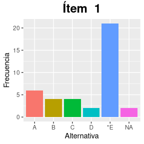

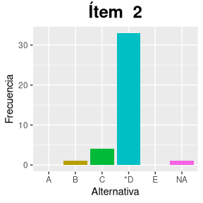

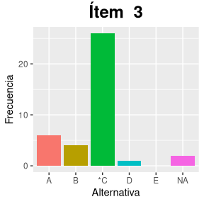

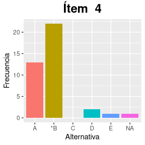

```r
g <- graficarFrecuenciaAlternativas(respuestas, alternativas, clave)
g$i01
g$i02
g$i03
g$i04
```

### Análisis de distractores

Tabular la frecuencia en que cada alternativa es seleccionada por los estudiantes con mejor y peor desempeño es un tipo de análisis sencillo y fácil de interpretar.

Para realizar este análisis primero hay que en ordenar a los estudiantes por el puntaje obtenido en la prueba. A continuación se seleccionan un porcentaje de estudiantes con la puntuación más baja y más alta. Suele usarse el 25% en cada caso. Otros valores razonables son 27% y 33%. Por último, se tabulan las respuestas seleccionadas por el grupo superior e inferior.

```r
ad <- analizarAlternativas(respuestas, clave, alternativas, proporcion = 0.25)
ad$i01
```

```
#>      A B C D *E
#> gSup 0 0 0 1  9
#> gInf 1 0 1 1  6
```

```r
ad$i25
```

```
#>      A B C D *E
#> gSup 0 1 3 1  3
#> gInf 4 2 1 0  0
```

```r
ad$i50
```

```
#>      A B C *D E
#> gSup 1 0 0  8 1
#> gInf 0 1 0  4 1
```

Con esta tabulación es posible determinar buenos y malos distractores, así como también el poder de discriminación de un ítem.

## Análisis gráfico de ítems

El análisis gráfico de ítems consiste en mostrar visualmente, mediante una gráfica de líneas, la relación entre la puntuación total de la prueba y la proporción de respuestas de los examinados que eligieron cada alternativa. Este análisis proporciona información esencial y fácilmente interpretable acerca de las características técnicas del ítem: dificultad, discriminación.

Para realizar este análisis primero se clasifica a los estudiantes en 4 grupos según su puntaje obtenido en la prueba. El grupo 1 corresponde a los estudiantes con menores puntuaciones, mientras que el grupo 4, a los de mayores puntajes. En el gráfico se representa la proporción de estudiantes de cada grupo que seleccionó una alternativa dada.

```r
item <- agi(respuestas, clave, alternativas)

item$i01$datos
```

```
#>         grupo    A    B    C    D   *E
#> 1 (4.96,14.5] 0.12 0.00 0.00 0.12 0.62
#> 2   (14.5,24] 0.26 0.21 0.16 0.00 0.32
#> 3   (24,33.5] 0.00 0.00 0.12 0.12 0.75
#> 4   (33.5,43] 0.00 0.00 0.00 0.00 1.00
```

```r
item$i25$datos
```

```
#>         grupo    A    B    C    D   *E
#> 1 (4.96,14.5] 0.38 0.25 0.00 0.00 0.00
#> 2   (14.5,24] 0.11 0.37 0.26 0.11 0.11
#> 3   (24,33.5] 0.00 0.12 0.25 0.12 0.25
#> 4   (33.5,43] 0.00 0.25 0.25 0.25 0.25
```

```r
item$i50$datos
```

```
#>         grupo    A    B    C   *D    E
#> 1 (4.96,14.5] 0.00 0.12 0.00 0.25 0.12
#> 2   (14.5,24] 0.00 0.16 0.26 0.42 0.11
#> 3   (24,33.5] 0.25 0.00 0.00 0.62 0.12
#> 4   (33.5,43] 0.00 0.00 0.00 1.00 0.00
```

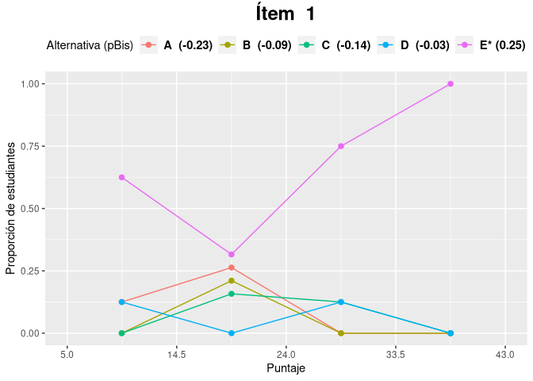

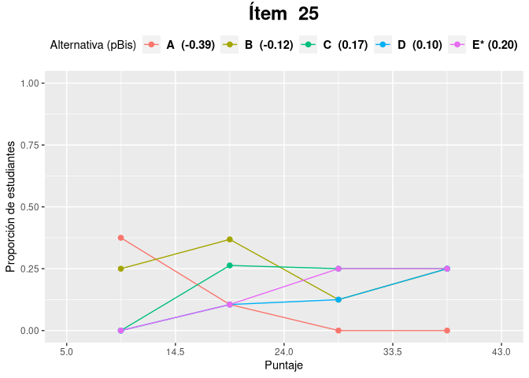

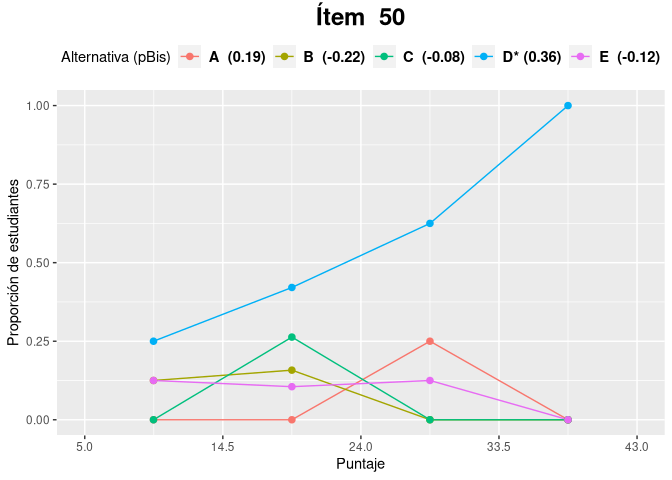

```r
item$i01$plot
item$i25$plot
item$i50$plot
```

Un ítem de buena calidad debería mostrar una proporción creciente de estudiantes de cada grupo que elije la alternativa correcta y una proporción decreciente en el caso de los distractores.

## Referencias

- Morales, P. (2009). Análisis de ítem en las pruebas objetivas. Madrid. Recuperado de [análisis de ítems](https://educrea.cl/wp-content/uploads/2014/11/19-nov-analisis-de-items-en-las-pruebas-objetivas.pdf)
- Guadalupe de los Santos (2010). Manual para el análisis gráfico de ítems. Universidad Autónoma de Baja California. Recuperado de [manual_pagi.pdf](http://www.educacionbc.edu.mx/departamentos/evaluacion/eacademicos/archivos/jornadasBC/MANUAL_PAGI.pdf)